# Join Lab

Dr. Shoemaker

DATA 2401

# Joins and `dplyr` practice

## Dataset 1

We start by making some “healthcare” data:

```r
library(tidyverse) ## add this line! (and fix line 98)
# Patients table
patients <- tibble(
  patient_id = c(1, 2, 3, 4),
  name = c("Alice", "Bob", "Charlie", "David"),
  age = c(25, 40, 35, 50),
  sex = c("F", "M", "F", "M")
)

# Visits table (Some patients have multiple visits, some missing)
visits <- tibble(
  visit_id = c(101, 102, 103, 104, 105),
  patient_id = c(1, 2, 2, 3, 5),
  doctor_id = c(201, 202, 201, 203, 204),
  visit_date = as.Date(c("2024-01-10", "2024-01-12", "2024-02-15", "2024-03-01", "2024-03-10"))
)

# Doctors table (Some doctors may not have treated any patients)
doctors <- tibble(
  doctor_id = c(201, 202, 203, 205),
  doctor_name = c("Dr. Smith", "Dr. Johnson", "Dr. Lee", "Dr. Brown"),
  specialty = c("Cardiology", "Neurology", "Pediatrics", "Orthopedics")
)
```

Questions:

- Find the names of patients who have visited the hospital.
- Show all patients visit information, even if they haven’t visited the hospital
- List all the visits and patient information, even if there isn’t information for the patient
- Show all visits with their assigned doctors.
- Find the doctor(s) that Bob has met with.
- Find patients that haven’t visited the hospital

```r
# - Find the names of patients who have visited the hospital.
semi_join(patients, visits) |> select(name)
```

```
## # A tibble: 3 × 1
##   name
##   <chr>
## 1 Alice
## 2 Bob
## 3 Charlie
```

```r
# - Show all patients' visit information, even if they haven't visited the hospital
left_join(patients, visits)
```

```
## # A tibble: 5 × 7
##   patient_id name      age sex   visit_id doctor_id visit_date
##        <dbl> <chr>   <dbl> <chr>    <dbl>     <dbl> <date>
## 1          1 Alice      25 F          101       201 2024-01-10
## 2          2 Bob        40 M          102       202 2024-01-12
## 3          2 Bob        40 M          103       201 2024-02-15
## 4          3 Charlie    35 F          104       203 2024-03-01
## 5          4 David      50 M           NA        NA NA
```

```r
# - List all the visits with their patient information, even if there isn't information for the patient
left_join(visits, patients)
```

```
## # A tibble: 5 × 7
##   visit_id patient_id doctor_id visit_date name      age sex
##      <dbl>      <dbl>     <dbl> <date>     <chr>   <dbl> <chr>
## 1      101          1       201 2024-01-10 Alice      25 F
## 2      102          2       202 2024-01-12 Bob        40 M
## 3      103          2       201 2024-02-15 Bob        40 M
## 4      104          3       203 2024-03-01 Charlie    35 F
## 5      105          5       204 2024-03-10 <NA>       NA <NA>
```

```r
## or
right_join(patients, visits)
```

```
## # A tibble: 5 × 7
##   patient_id name      age sex   visit_id doctor_id visit_date
##        <dbl> <chr>   <dbl> <chr>    <dbl>     <dbl> <date>
## 1          1 Alice      25 F          101       201 2024-01-10
## 2          2 Bob        40 M          102       202 2024-01-12
## 3          2 Bob        40 M          103       201 2024-02-15
## 4          3 Charlie    35 F          104       203 2024-03-01
## 5          5 <NA>       NA <NA>       105       204 2024-03-10
```

```r
# - Show all visits with their assigned doctors.
left_join(visits, doctors, join_by(doctor_id)) ## do I need this join_by? no.
```

```
## # A tibble: 5 × 6
##   visit_id patient_id doctor_id visit_date doctor_name specialty
##      <dbl>      <dbl>     <dbl> <date>     <chr>       <chr>
## 1      101          1       201 2024-01-10 Dr. Smith   Cardiology
## 2      102          2       202 2024-01-12 Dr. Johnson Neurology
## 3      103          2       201 2024-02-15 Dr. Smith   Cardiology
## 4      104          3       203 2024-03-01 Dr. Lee     Pediatrics
## 5      105          5       204 2024-03-10 <NA>        <NA>
```

```r
# - Find the doctor(s) that Bob has met with.
## this one needs two joins!
## how do I get this!? I need Bob's name, his visits, and the doctors for each visit.
left_join(patients, visits) |>
  filter(name == "Bob") |>  ## take the result and filter to only Bob
  left_join(doctors) |>  ## join this new "only bob visits" data with the matching doctors
  select(doctor_name)  ## only show the doctor vector
```

```
## # A tibble: 2 × 1
##   doctor_name
##   <chr>
## 1 Dr. Johnson
## 2 Dr. Smith
```

```r
# - Find patients that haven't visited the hospital
anti_join(patients, visits)
```

```
## # A tibble: 1 × 4
##   patient_id name    age sex
##        <dbl> <chr> <dbl> <chr>
## 1          4 David    50 M
```

## Dataset 2

Load the `"nycflights13"` package. You’ll also need to load `dplyr` or `tidyverse`, if you didn’t above.

```r
library(tidyverse)
#install.packages("nycflights13")
library(nycflights13)
my_flights <- flights # store my own version
my_flights <- na.omit(my_flights)
  ## this dataset has data on cancelled flights too,
  ## so we 'll remove those for now
```

Create a dataframe of the average arrival delays for each *destination*

```r
avg_arr_delay_df <- my_flights |>
  group_by(dest) |>
  summarise(avg_arr_delay = mean(arr_delay)) |>
  arrange(-avg_arr_delay)
```

Then use `left_join()` to join on the “airports” dataframe, which has the airport information.

```r
data("airports") # this will put the data in your environment (optional)
left_join(avg_arr_delay_df, airports, join_by(dest == faa)) |> select(avg_arr_delay, name)
```

```
## # A tibble: 104 × 2
##    avg_arr_delay name
##            <dbl> <chr>
##  1          41.8 Columbia Metropolitan
##  2          33.7 Tulsa Intl
##  3          30.6 Will Rogers World
##  4          28.1 Jackson Hole Airport
##  5          24.1 Mc Ghee Tyson
##  6          20.2 Dane Co Rgnl Truax Fld
##  7          20.1 Richmond Intl
##  8          19.7 Akron Canton Regional Airport
##  9          19.0 Des Moines Intl
## 10          18.2 Gerald R Ford Intl
## # ℹ 94 more rows
```

Note here: the column names don’t match anymore!

Which airport had the largest average arrival delay?

```r
left_join(avg_arr_delay_df, airports, join_by(dest == faa)) |>
  select(avg_arr_delay, name) |>
  slice_max(avg_arr_delay)
```

```
## # A tibble: 1 × 2
##   avg_arr_delay name
##           <dbl> <chr>
## 1          41.8 Columbia Metropolitan
```

What is the average departure delay for each airline? To answer this with something more than just the FAA code of the airline name, you need to create a dataframe of the average departure delay for each *airline*, then use `left_join()` to join on the “airlines” dataframe

```r
my_flights |>
  summarise(avg_dep_delay = mean(dep_delay),
            .by = carrier) |>
  left_join(airlines) |>
  select(name, avg_dep_delay)
```

```
## # A tibble: 16 × 2
##    name                        avg_dep_delay
##    <chr>                               <dbl>
##  1 United Air Lines Inc.               12.0
##  2 American Airlines Inc.               8.57
##  3 JetBlue Airways                     13.0
##  4 Delta Air Lines Inc.                 9.22
##  5 ExpressJet Airlines Inc.            19.8
##  6 Envoy Air                           10.4
##  7 US Airways Inc.                      3.74
##  8 Southwest Airlines Co.              17.7
##  9 Virgin America                      12.8
## 10 AirTran Airways Corporation         18.6
## 11 Alaska Airlines Inc.                 5.83
## 12 Endeavor Air Inc.                   16.4
## 13 Frontier Airlines Inc.              20.2
## 14 Hawaiian Airlines Inc.               4.90
## 15 Mesa Airlines Inc.                  18.9
## 16 SkyWest Airlines Inc.               12.6
```

```r
## get rid of one of the tick marks below - should be 3
```

Which airline had the smallest average departure delay?

```r
my_flights |>
  summarise(avg_dep_delay = mean(dep_delay),
            .by = carrier) |>
  left_join(airlines) |>
  select(name, avg_dep_delay) |>
  arrange(avg_dep_delay)
```

```
## # A tibble: 16 × 2
##    name                        avg_dep_delay
##    <chr>                               <dbl>
##  1 US Airways Inc.                      3.74
##  2 Hawaiian Airlines Inc.               4.90
##  3 Alaska Airlines Inc.                 5.83
##  4 American Airlines Inc.               8.57
##  5 Delta Air Lines Inc.                 9.22
##  6 Envoy Air                           10.4
##  7 United Air Lines Inc.               12.0
##  8 SkyWest Airlines Inc.               12.6
##  9 Virgin America                      12.8
## 10 JetBlue Airways                     13.0
## 11 Endeavor Air Inc.                   16.4
## 12 Southwest Airlines Co.              17.7
## 13 AirTran Airways Corporation         18.6
## 14 Mesa Airlines Inc.                  18.9
## 15 ExpressJet Airlines Inc.            19.8
## 16 Frontier Airlines Inc.              20.2
```

```r
## OR

my_flights |>
  summarise(avg_dep_delay = mean(dep_delay),
            .by = carrier) |>
  left_join(airlines) |>
  select(name, avg_dep_delay) |>
  slice_min(avg_dep_delay)
```

```
## # A tibble: 1 × 2
##   name            avg_dep_delay
##   <chr>                   <dbl>
## 1 US Airways Inc.          3.74
```

Add origin and destination airport names (two joins to the same table) Question: Which origin–destination pair has the highest average arrival delay?

```r
my_flights |>
  left_join(airports, join_by(origin == faa)) |>
  left_join(airports, join_by(dest == faa), suffix = c("_origin", "_dest"))
```

```
## # A tibble: 327,346 × 33
##     year month   day dep_time sched_dep_time dep_delay arr_time sched_arr_time
##    <int> <int> <int>    <int>          <int>     <dbl>    <int>          <int>
##  1  2013     1     1      517            515         2      830            819
##  2  2013     1     1      533            529         4      850            830
##  3  2013     1     1      542            540         2      923            850
##  4  2013     1     1      544            545        -1     1004           1022
##  5  2013     1     1      554            600        -6      812            837
##  6  2013     1     1      554            558        -4      740            728
##  7  2013     1     1      555            600        -5      913            854
##  8  2013     1     1      557            600        -3      709            723
##  9  2013     1     1      557            600        -3      838            846
## 10  2013     1     1      558            600        -2      753            745
## # ℹ 327,336 more rows
## # ℹ 25 more variables: arr_delay <dbl>, carrier <chr>, flight <int>,
## #   tailnum <chr>, origin <chr>, dest <chr>, air_time <dbl>, distance <dbl>,
## #   hour <dbl>, minute <dbl>, time_hour <dttm>, name_origin <chr>,
## #   lat_origin <dbl>, lon_origin <dbl>, alt_origin <dbl>, tz_origin <dbl>,
## #   dst_origin <chr>, tzone_origin <chr>, name_dest <chr>, lat_dest <dbl>,
## #   lon_dest <dbl>, alt_dest <dbl>, tz_dest <dbl>, dst_dest <chr>, …
```

```r
    ## we can add this suffix to make it clear which columns are for the origin (from the first join) and which are from the destination (from the second join)

my_flights |>
  left_join(airports, join_by(origin == faa)) |>
  left_join(airports, join_by(dest == faa), suffix = c("_origin", "_dest")) |>
  summarise(mean_arr_delay = mean(arr_delay),
            n_flights = n(),
            .by = c(name_origin, name_dest)) |>
    ## grouping by the new names so that they stick around
  arrange(-mean_arr_delay) |>
  select(mean_arr_delay, n_flights, name_origin, name_dest)
```

```
## # A tibble: 218 × 4
##    mean_arr_delay n_flights name_origin         name_dest
##             <dbl>     <int> <chr>               <chr>
##  1           44.6        94 Newark Liberty Intl Columbia Metropolitan
##  2           41.2       313 Newark Liberty Intl Mc Ghee Tyson
##  3           33.7       294 Newark Liberty Intl Tulsa Intl
##  4           30.6       315 Newark Liberty Intl Will Rogers World
##  5           29.9        19 Newark Liberty Intl Jackson Hole Airport
##  6           25.8      1615 Newark Liberty Intl Richmond Intl
##  7           24.0      1058 Newark Liberty Intl General Mitchell Intl
##  8           23.5       390 Newark Liberty Intl Des Moines Intl
##  9           23.2       345 Newark Liberty Intl Dane Co Rgnl Truax Fld
## 10           23.0       730 Newark Liberty Intl Portland Intl Jetport
## # ℹ 208 more rows
```

Which airline (name) has the highest on-time rate? Are left_join and inner_join returning the same rows here? Why?

```r
my_flights |>
  left_join(airlines) |>
  mutate(on_time = arr_delay <= 5) |>
  summarise(on_time_count = sum(on_time),
            flight_count = n(),
            on_time_perc = on_time_count / flight_count * 100,
            .by = name) |>
  slice_max(on_time_perc, n = 4)
```

```
## # A tibble: 4 × 4
##   name                   on_time_count flight_count on_time_perc
##   <chr>                          <int>        <int>        <dbl>
## 1 Alaska Airlines Inc.             552          709         77.9
## 2 Hawaiian Airlines Inc.           266          342         77.8
## 3 Virgin America                  3726         5116         72.8
## 4 American Airlines Inc.         23201        31947         72.6
```

```r
dim(my_flights |> left_join(airlines)) == dim(my_flights |> inner_join(airlines))
```

```
## [1] TRUE TRUE
```

```r
## same number of rows and columns - this tells us that there isn't a carrier in the data that's missing in the lookup table
```

Plane metadata join: age of aircraft vs. delays Among aircraft with at least 50 flights, which tailnumber has the largest average arrival delay, and what are the manufacturer/model and age?

```r
my_flights |>
  left_join(planes, join_by(tailnum)) |>
  add_count(tailnum, name = "n_flights_of_plane") |>
    ## counts the flights for each plane, adds it as a column!
  filter(n_flights_of_plane >= 50) |>
  summarise(avg_arr_delay = mean(arr_delay),
            .by = c(tailnum, manufacturer, year.y)) |>
  arrange(-avg_arr_delay)
```

```
## # A tibble: 2,086 × 4
##    tailnum manufacturer   year.y avg_arr_delay
##    <chr>   <chr>           <int>         <dbl>
##  1 N11119  EMBRAER          2002          30.3
##  2 N16919  EMBRAER          2001          29.9
##  3 N989AT  BOEING           2001          28.2
##  4 N14998  EMBRAER          2000          27.9
##  5 N15910  EMBRAER          2001          27.6
##  6 N8698A  BOMBARDIER INC   2002          27.5
##  7 N13123  EMBRAER          2003          26.0
##  8 N11192  EMBRAER          2005          25.9
##  9 N14950  EMBRAER          1998          25.3
## 10 N21130  EMBRAER          2003          25.0
## # ℹ 2,076 more rows
```

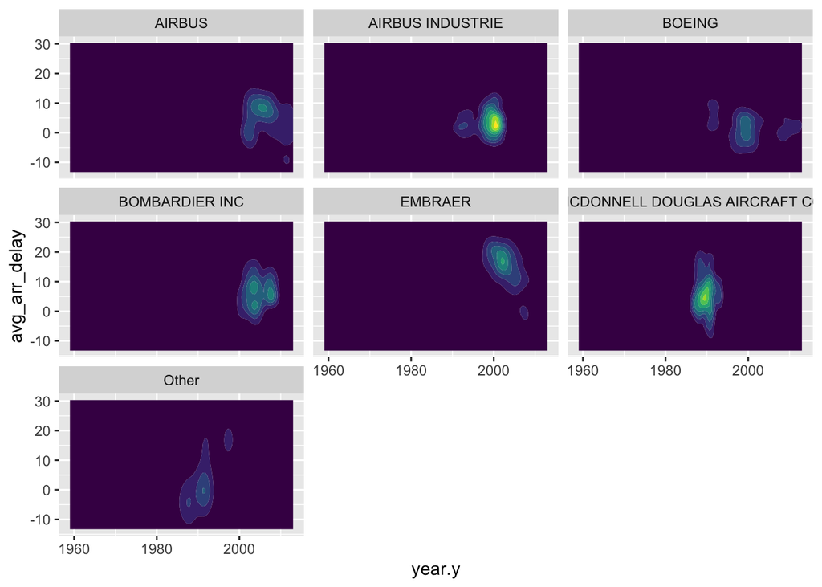

```r
my_flights |>
  left_join(planes, join_by(tailnum)) |>
  add_count(tailnum, name = "n_flights_of_plane") |>
    ## counts the flights for each plane, adds it as a column!
  filter(n_flights_of_plane >= 50) |>
  summarise(avg_arr_delay = mean(arr_delay),
            .by = c(tailnum, manufacturer, year.y)) |>
  drop_na(year.y) |>
  mutate(man_simp = fct_lump_n(manufacturer, n = 6)) |>
  ggplot(aes(x = year.y, y = avg_arr_delay)) +
  geom_density_2d_filled() +
  facet_wrap(~ man_simp) +
  theme(legend.position = "none")
```

## Extra Examples from R4DS:

```r
top_dest <- flights %>%
  count(dest, sort = TRUE) %>%
  head(10)
top_dest
```

```
## # A tibble: 10 × 2
##    dest      n
##    <chr> <int>
##  1 ORD   17283
##  2 ATL   17215
##  3 LAX   16174
##  4 BOS   15508
##  5 MCO   14082
##  6 CLT   14064
##  7 SFO   13331
##  8 FLL   12055
##  9 MIA   11728
## 10 DCA    9705
```

Now you want to find each flight that went to one of those destinations. You could, of course, filter. But! Now you can semi-join:

```r
flights %>%
  semi_join(top_dest)
```

```
## # A tibble: 141,145 × 19
##     year month   day dep_time sched_dep_time dep_delay arr_time sched_arr_time
##    <int> <int> <int>    <int>          <int>     <dbl>    <int>          <int>
##  1  2013     1     1      542            540         2      923            850
##  2  2013     1     1      554            600        -6      812            837
##  3  2013     1     1      554            558        -4      740            728
##  4  2013     1     1      555            600        -5      913            854
##  5  2013     1     1      557            600        -3      838            846
##  6  2013     1     1      558            600        -2      753            745
##  7  2013     1     1      558            600        -2      924            917
##  8  2013     1     1      558            600        -2      923            937
##  9  2013     1     1      559            559         0      702            706
## 10  2013     1     1      600            600         0      851            858
## # ℹ 141,135 more rows
## # ℹ 11 more variables: arr_delay <dbl>, carrier <chr>, flight <int>,
## #   tailnum <chr>, origin <chr>, dest <chr>, air_time <dbl>, distance <dbl>,
## #   hour <dbl>, minute <dbl>, time_hour <dttm>
```

What does anti_join(flights, airports, by = c(“dest” = “faa”)) tell you? What does anti_join(airports, flights, by = c(“faa” = “dest”)) tell you? Perform the two joins below and consider what the results **are**.

```r
anti_join(flights, airports, by = c("dest" = "faa"))
```

```
## # A tibble: 7,602 × 19
##     year month   day dep_time sched_dep_time dep_delay arr_time sched_arr_time
##    <int> <int> <int>    <int>          <int>     <dbl>    <int>          <int>
##  1  2013     1     1      544            545        -1     1004           1022
##  2  2013     1     1      615            615         0     1039           1100
##  3  2013     1     1      628            630        -2     1137           1140
##  4  2013     1     1      701            700         1     1123           1154
##  5  2013     1     1      711            715        -4     1151           1206
##  6  2013     1     1      820            820         0     1254           1310
##  7  2013     1     1      820            820         0     1249           1329
##  8  2013     1     1      840            845        -5     1311           1350
##  9  2013     1     1      909            810        59     1331           1315
## 10  2013     1     1      913            918        -5     1346           1416
## # ℹ 7,592 more rows
## # ℹ 11 more variables: arr_delay <dbl>, carrier <chr>, flight <int>,
## #   tailnum <chr>, origin <chr>, dest <chr>, air_time <dbl>, distance <dbl>,
## #   hour <dbl>, minute <dbl>, time_hour <dttm>
```

```r
## these are the flights going to airports that aren't in the "airports" lookup table

anti_join(airports, flights, by = c("faa" = "dest"))
```

```
## # A tibble: 1,357 × 8
##    faa   name                             lat    lon   alt    tz dst   tzone
##    <chr> <chr>                          <dbl>  <dbl> <dbl> <dbl> <chr> <chr>
##  1 04G   Lansdowne Airport               41.1  -80.6  1044    -5 A     America/…
##  2 06A   Moton Field Municipal Airport   32.5  -85.7   264    -6 A     America/…
##  3 06C   Schaumburg Regional             42.0  -88.1   801    -6 A     America/…
##  4 06N   Randall Airport                 41.4  -74.4   523    -5 A     America/…
##  5 09J   Jekyll Island Airport           31.1  -81.4    11    -5 A     America/…
##  6 0A9   Elizabethton Municipal Airport  36.4  -82.2  1593    -5 A     America/…
##  7 0G6   Williams County Airport         41.5  -84.5   730    -5 A     America/…
##  8 0G7   Finger Lakes Regional Airport   42.9  -76.8   492    -5 A     America/…
##  9 0P2   Shoestring Aviation Airfield    39.8  -76.6  1000    -5 U     America/…
## 10 0S9   Jefferson County Intl           48.1 -123.    108    -8 A     America/…
## # ℹ 1,347 more rows
```

```r
## these are the airports in the lookup table that are not the destination of flights from NYC
```